# 6.4 Considerations in High Dimensions

Timothy Tickle  
February 6, 2015

### Statistics in the Low-dimensions

The low-dimensional setting.

- Simply when the number of observations (n) are greater than the number of features (p).
  - n > p

### Example of the Low-dimensional Setting

Predicting blood pressure from age, gender, and BMI.

- Thousands of patients with information available (n)
- 3 predictors (p)
- (1000s) n >> (3) p

### Statistics in the High-dimensional Setting

- When the number of observations are less than the number of features
  - p > n
  - p >> n
  - p = n

### High Dimensional Data is Common

Medical Research

- Studying Obesity
  - Age, Sex, BMI, 500,000 SNPs in 1000 patients
  - 500,003 (p) >> 1000 (n)

[figure not shown]

### High Dimensional Data is Common

Big Data-

- Many points of data are collected
- Netflix
  - Every movie you watch and rate
  - Is this a high-dimensional or low-dimensional setting?

### Low-dimensional Setting Concepts Apply

Concepts we have learned still apply

- Bias-variance trade-off
- Danger of overfitting

Some algorithms we have studied are not good choices

- (e.g.)
  - Least Squares Linear Regression,
  - Logistic Regression
  - LDA

### Least Squares LM: A Cautionary Tale

Special care is needed for algorithm selection and interpretation of results.

Least Squares will ALWAYS yield a set of coefficient estimates that result in a perfect fit to the data (residuals = zero). Even if there is NO true relationship.

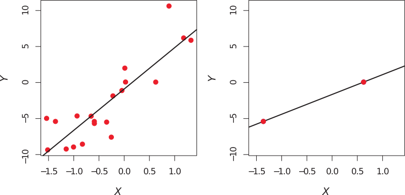

### How Does This Apply to prediction?

Least Squares LM is too flexible in the high-dimensional setting.

- You will overfit you data in your training set.
- You will perform poorly in your test.
- Your model will not be useful.

### Least Squares LM Performs Worse as Dimensions Increase

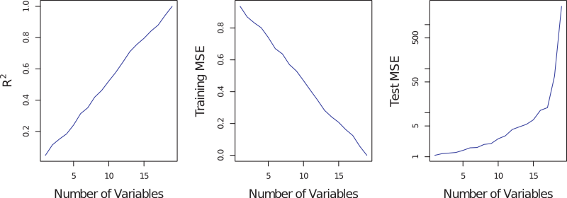

- All features unrelated to predictor
- Model R<sup>2</sup> increases as predictors are added (Seems good)
- Model MSE decreases as predictors are added (Seems good)
- Prediction MSE gets large as predictors are added (Very bad)

### But We Already Learned this, Adjust R^2

Nope.

### But We Already Learned this, Adjust R^2

But to be more specific…

- \( \hat{\sigma^2} = 0 \)
- Cp = \( \frac{1}{n}(RSS+2d\hat{\sigma^2}) \) = \( \frac{0}{n} \)
- AIC = \( \frac{1}{n\hat{\sigma}^2}(RSS+2d\hat{\sigma^2}) \) = \( \frac{0}{0} \)
- BIC = \( \frac{1}{n}(RSS+log(n)d\hat{\sigma^2}) \) = \( \frac{0}{n} \)
- Adj R<sup>2</sup> = \( 1 - \frac{\frac{RSS}{n-d-1}}{\frac{TSS}{n-1}} \) = \( 1 - \frac{0}{\frac{TSS}{n-1}} \) = 1

### There is Hope!

Be less flexible and avoid overfitting!

- Forward stepwise selection
- Ridge regression
- The LASSO
- Principal Components Regression

### LASSO in Progressively High Dimensions

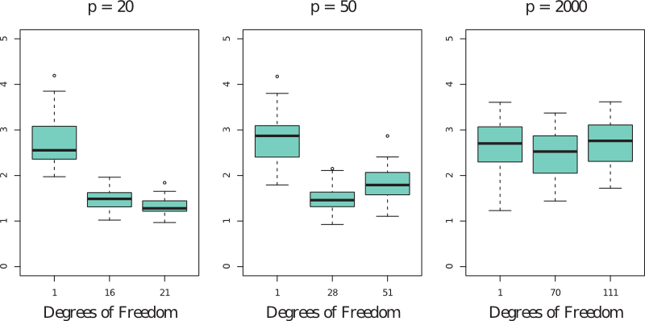

### Reduce Features, Tune, and Know Your Features!

1. Regularization / shrinkage is key
2. Tuning parameter selection is crucial for good performance
3. As dimensions increase test error increases
   - Unless the new features are truly associated with the response
   - Curse of dimensionality
   - Adding new features adds noise which may be spuriously associated with the response.
     - And so overfitting.

### Food for Thought

We see new technologies which are expensive but yield many measurements on individuals. This forces a high dimensional setting. These technologies will only increase predictive power if they provide informative features, otherwise they make the task of prediction worse.

[figure not shown]

### Interpreting Results in High Dimensions

[figure not shown]

**Multicollinearity** Variables in a matrix might be correlated with each other.

**Multicollinearity (HD)** Any variable in the model can be written as a linear combination of all the other variables in the model.

We can NEVER know which variable is TRULY predictive.

### Interpreting the SNP Study

In our previous study we find 17 SNPs lead to a good predictive model on the training data.

What can we conclude?

### Interpreting the SNP Study

This is one set of 17 SNPs (one model) out of MANY possible models in the data set.

Further validation on independent data sets is needed.

### Don't Forget

Never use the following measures on **TRAINING** data as evidence of a good model fit in the HD Setting:

- Sum of Squared Errors
- P-values
- R<sup>2</sup> or other traditional measure of model fit

Report these metrics on independent data sets.

### Only the beginning...

[figure not shown]

You are well on your way to becoming a ninja in high-dimensions!